# --- **Capstone-Projekt** --- Entwicklung der Finanzsystem-Stabilität und finanzieller Inklusion über die Zeit und während Krisen. Ein Blick auf Deutschland im Vergleich zu Europa, Asien und den USA.

```python
import os

import pandas as pd
import numpy as np

import seaborn as sns
import matplotlib.pyplot as plt
```

```python
sns.set_theme(style='darkgrid')
```

# Datensatz

- **Global Financial Development von World Bank**
- Quelle: https://databank.worldbank.org/source/global-financial-development#
- Auswahl:
  - Database: Global Financial Development
  - Country: All
  - Series: All
  - Time: All
- Glossary zum Datensatz: https://databank.worldbank.org/metadataglossary/Global-Financial-Development/series/viewall

## Was ist die World Bank?

Die Weltbank ist eine Sonderorganisation der Vereinten Nationen und verfolgt das Ziel, die weltweite Armut durch eine nachhaltige wirtschaftliche Entwicklung ärmerer Staaten zu reduzieren.

Die Weltbankgruppe geht auf die Internationalen Bank für Wiederaufbau und Entwicklung zurück, die im Jahre 1944 gegründet wurde. Hauptsitz der Weltbankgruppe ist Washington D.C.. Die Gruppe besteht aus den folgenden fünf Organisationen, die alle eigenständig agieren und sich im Besitz ihrer jeweiligen Mitgliedstaaten befinden:

- Internationale Bank für Wiederaufbau und Entwicklung IBRD (187 Mitgliedstaaten)
- Internationale Entwicklungsorganisation IDA (170 Mitgliedstaaten)
- Internationale Finanz-Corporation IFC (182 Mitgliedstaaten)
- Multilaterale Investitions-Garantie-Agentur MIGA (175 Mitgliedstaaten)
- Internationales Zentrum zur Beilegung von Investitionsstreitigkeiten ICSID (147 Mitgliedstaaten)

Mit dem Begriff "Weltbank" werden hierbei in der Regel die beiden erstgenannten Organisationen bezeichnet; der Begriff "Weltbankgruppe" hingegen umfasst alle fünf Organisationen.

*Quelle: https://www.destatis.de/DE/Themen/Laender-Regionen/Internationales/Datenquellen/42_00_WorldBank.html*

## Datei einlesen

```python
path = os.path.join("C:\\","Users","kitte","Downloads","P_Data_Extract_From_Global_Financial_Development")
df_raw = pd.read_csv(os.path.join(path, "c2c51d9f-9869-4c9d-919b-bc66c292148e_Data.csv"), encoding='latin-1')

df_raw.head()
```

|  | Country Name | Country Code | Series Name | Series Code | 1960 [YR1960] | 1961 [YR1961] | 1962 [YR1962] | 1963 [YR1963] | 1964 [YR1964] | 1965 [YR1965] | ... | 2012 [YR2012] | 2013 [YR2013] | 2014 [YR2014] | 2015 [YR2015] | 2016 [YR2016] | 2017 [YR2017] | 2018 [YR2018] | 2019 [YR2019] | 2020 [YR2020] | 2021 [YR2021] |
| --- | --- | --- | --- | --- | --- | --- | --- | --- | --- | --- | --- | --- | --- | --- | --- | --- | --- | --- | --- | --- | --- |
| 0 | Afghanistan | AFG | 5-bank asset concentration | GFDD.OI.06 | .. | .. | .. | .. | .. | .. | ... | 84.82737 | 79.66876 | 86.60348 | 72.15488 | 71.94055 | 73.68089 | 79.18661 | 78.21213 | 77.36341 | 83.09309 |
| 1 | Afghanistan | AFG | Account at a formal financial institution (% a... | GFDD.AI.05 | .. | .. | .. | .. | .. | .. | ... | .. | .. | 9.961001 | .. | .. | 14.54708 | .. | .. | .. | 9.653822 |
| 2 | Afghanistan | AFG | Account used for business purposes (% age 15+) | GFDD.AI.08 | .. | .. | .. | .. | .. | .. | ... | .. | .. | 8.322865 | .. | .. | 3.366648 | .. | .. | .. | .. |
| 3 | Afghanistan | AFG | Account used to receive government payments (%... | GFDD.AI.09 | .. | .. | .. | .. | .. | .. | ... | .. | .. | .. | .. | .. | .. | .. | .. | .. | .. |
| 4 | Afghanistan | AFG | Account used to receive remittances (% age 15+) | GFDD.AI.10 | .. | .. | .. | .. | .. | .. | ... | .. | .. | 1.690978 | .. | .. | .. | .. | .. | .. | 0.4780855 |

5 rows × 66 columns

```python
# Kopie des Rohdatensatzes erstellen, um die Rohdaten (df_raw) unverändert zu lassen
# gearbeitet wird ab jetzt mit der Datensatzkopie (df)
df = df_raw.copy()
```

## Spaltennamen vereinfachen

- Jahreszahlen als Datentyp int
- 'Country Name' vereinfacht als 'Country'
- 'Series Name' vereinfach als 'Series'

```python
# Liste mit sauberen Jahreszahlen im Integer-Format erstellen
years = []
for year in df_raw.columns[4:]:
    years.append(int(year[0:4]))

# Spaltennamen ändern/vereinfachen
column_names = [
'Country', 'Country Code', 'Series', 'Series Code'
] + years

df.columns=column_names
df
```

|  | Country | Country Code | Series | Series Code | 1960 | 1961 | 1962 | 1963 | 1964 | 1965 | ... | 2012 | 2013 | 2014 | 2015 | 2016 | 2017 | 2018 | 2019 | 2020 | 2021 |
| --- | --- | --- | --- | --- | --- | --- | --- | --- | --- | --- | --- | --- | --- | --- | --- | --- | --- | --- | --- | --- | --- |
| 0 | Afghanistan | AFG | 5-bank asset concentration | GFDD.OI.06 | .. | .. | .. | .. | .. | .. | ... | 84.82737 | 79.66876 | 86.60348 | 72.15488 | 71.94055 | 73.68089 | 79.18661 | 78.21213 | 77.36341 | 83.09309 |
| 1 | Afghanistan | AFG | Account at a formal financial institution (% a... | GFDD.AI.05 | .. | .. | .. | .. | .. | .. | ... | .. | .. | 9.961001 | .. | .. | 14.54708 | .. | .. | .. | 9.653822 |
| 2 | Afghanistan | AFG | Account used for business purposes (% age 15+) | GFDD.AI.08 | .. | .. | .. | .. | .. | .. | ... | .. | .. | 8.322865 | .. | .. | 3.366648 | .. | .. | .. | .. |
| 3 | Afghanistan | AFG | Account used to receive government payments (%... | GFDD.AI.09 | .. | .. | .. | .. | .. | .. | ... | .. | .. | .. | .. | .. | .. | .. | .. | .. | .. |
| 4 | Afghanistan | AFG | Account used to receive remittances (% age 15+) | GFDD.AI.10 | .. | .. | .. | .. | .. | .. | ... | .. | .. | 1.690978 | .. | .. | .. | .. | .. | .. | 0.4780855 |
| ... | ... | ... | ... | ... | ... | ... | ... | ... | ... | ... | ... | ... | ... | ... | ... | ... | ... | ... | ... | ... | ... |
| 24300 | NaN | NaN | NaN | NaN | NaN | NaN | NaN | NaN | NaN | NaN | ... | NaN | NaN | NaN | NaN | NaN | NaN | NaN | NaN | NaN | NaN |
| 24301 | NaN | NaN | NaN | NaN | NaN | NaN | NaN | NaN | NaN | NaN | ... | NaN | NaN | NaN | NaN | NaN | NaN | NaN | NaN | NaN | NaN |
| 24302 | NaN | NaN | NaN | NaN | NaN | NaN | NaN | NaN | NaN | NaN | ... | NaN | NaN | NaN | NaN | NaN | NaN | NaN | NaN | NaN | NaN |
| 24303 | Data from database: Global Financial Development | NaN | NaN | NaN | NaN | NaN | NaN | NaN | NaN | NaN | ... | NaN | NaN | NaN | NaN | NaN | NaN | NaN | NaN | NaN | NaN |
| 24304 | Last Updated: 09/23/2022 | NaN | NaN | NaN | NaN | NaN | NaN | NaN | NaN | NaN | ... | NaN | NaN | NaN | NaN | NaN | NaN | NaN | NaN | NaN | NaN |

24305 rows × 66 columns

## Prüfen auf fehlende Werte

```python
df.info()
```

```
<class 'pandas.core.frame.DataFrame'>
RangeIndex: 24305 entries, 0 to 24304
Data columns (total 66 columns):
 #   Column        Non-Null Count  Dtype
---  ------        --------------  -----
 0   Country       24302 non-null  object
 1   Country Code  24300 non-null  object
 2   Series        24300 non-null  object
 3   Series Code   24300 non-null  object
 4   1960          24300 non-null  object
 5   1961          24300 non-null  object
 6   1962          24300 non-null  object
 7   1963          24300 non-null  object
 8   1964          24300 non-null  object
 9   1965          24300 non-null  object
```

[output cut: 58 more lines]

```python
df.isnull().any().any()
```

```
True
```

```python
df.isnull().any()
```

```
Country         True
Country Code    True
Series          True
Series Code     True
1960            True
                ...
2017            True
2018            True
2019            True
2020            True
2021            True
Length: 66, dtype: bool
```

**Löschen unnötiger Zeilen**

- --> am Ende des Datensatzes befinden sich einige wenige leere Zeilen sowie anschließend eine Info zur Datenquelle
- diese Zeilen lassen sich leicht als NaN in der Spalte 'Country Code' identifizieren
- diese Zeilen werden entfernt

```python
# Entfernen leerer Zeilen, als Refernzspalte dient 'Country Code'
df.dropna(subset='Country Code', inplace=True)
df
```

|  | Country | Country Code | Series | Series Code | 1960 | 1961 | 1962 | 1963 | 1964 | 1965 | ... | 2012 | 2013 | 2014 | 2015 | 2016 | 2017 | 2018 | 2019 | 2020 | 2021 |
| --- | --- | --- | --- | --- | --- | --- | --- | --- | --- | --- | --- | --- | --- | --- | --- | --- | --- | --- | --- | --- | --- |
| 0 | Afghanistan | AFG | 5-bank asset concentration | GFDD.OI.06 | .. | .. | .. | .. | .. | .. | ... | 84.82737 | 79.66876 | 86.60348 | 72.15488 | 71.94055 | 73.68089 | 79.18661 | 78.21213 | 77.36341 | 83.09309 |
| 1 | Afghanistan | AFG | Account at a formal financial institution (% a... | GFDD.AI.05 | .. | .. | .. | .. | .. | .. | ... | .. | .. | 9.961001 | .. | .. | 14.54708 | .. | .. | .. | 9.653822 |
| 2 | Afghanistan | AFG | Account used for business purposes (% age 15+) | GFDD.AI.08 | .. | .. | .. | .. | .. | .. | ... | .. | .. | 8.322865 | .. | .. | 3.366648 | .. | .. | .. | .. |
| 3 | Afghanistan | AFG | Account used to receive government payments (%... | GFDD.AI.09 | .. | .. | .. | .. | .. | .. | ... | .. | .. | .. | .. | .. | .. | .. | .. | .. | .. |
| 4 | Afghanistan | AFG | Account used to receive remittances (% age 15+) | GFDD.AI.10 | .. | .. | .. | .. | .. | .. | ... | .. | .. | 1.690978 | .. | .. | .. | .. | .. | .. | 0.4780855 |
| ... | ... | ... | ... | ... | ... | ... | ... | ... | ... | ... | ... | ... | ... | ... | ... | ... | ... | ... | ... | ... | ... |
| 24295 | Zimbabwe | ZWE | Syndicated loan issuance volume to GDP (%) | GFDD.DM.12 | .. | .. | .. | .. | .. | .. | ... | .. | .. | .. | .. | .. | .. | 1.015702 | 0.3163197 | .. | 1.14045 |
| 24296 | Zimbabwe | ZWE | Total factoring volume to GDP (%) | GFDD.OI.18 | .. | .. | .. | .. | .. | .. | ... | .. | .. | .. | .. | .. | .. | .. | .. | .. | .. |
| 24297 | Zimbabwe | ZWE | Value of collateral needed for a loan (% of th... | GFDD.AI.31 | .. | .. | .. | .. | .. | .. | ... | .. | .. | .. | .. | 223.4 | .. | .. | .. | .. | .. |
| 24298 | Zimbabwe | ZWE | Value traded excluding top 10 traded companies... | GFDD.AM.01 | .. | .. | .. | .. | .. | .. | ... | .. | .. | .. | .. | .. | .. | .. | .. | .. | .. |
| 24299 | Zimbabwe | ZWE | Working capital financed by banks (%) | GFDD.AI.35 | .. | .. | .. | .. | .. | .. | ... | .. | .. | .. | .. | 5.8 | .. | .. | .. | .. | .. |

24300 rows × 66 columns

```python
df.isnull().any().any()
```

```
False
```

**--> Es befinden sich nun keine leeren Zeilen mehr im Datensatz!**

## Fehlende Werte korrekt kennzeichnen

**In den Spalten der Jahreszahlen sind leere Werte als Zeichenkette '..' eingetragen**

- ändern der Zeichenkette '..' in echte fehlende Werte (NaN)
- zunächst prüfen, in welchen Spalten die Zeichenkette '..' vorkommt: in den Spalten mit Text-Inhalten sollte die Zeichenkette '..' nicht ohne vorherige Prüfung überschrieben werden!

```python
# Prüfen, ob die Zeichenkette '..' auch in anderen Spalten als in den Jahresspalten auftaucht
for col in df.columns:
    leere_zeilen = len(df[df[col].str.contains('..', regex=False)])
    if leere_zeilen == 0:
        print(f"Spalte {col} enthält keine Zeichenkette '..'!")
```

```
Spalte Country enthält keine Zeichenkette '..'!
Spalte Country Code enthält keine Zeichenkette '..'!
Spalte Series enthält keine Zeichenkette '..'!
Spalte Series Code enthält keine Zeichenkette '..'!
```

**In den Text-Spalten befindet sich die Zeichenkette '..' nicht**  
**-> Zeichenkette '..' also kann im kompletten Datensatz gegen NaN getauscht werden**

```python
# Austauschen der Zeichenkette '..', die für fehlende Werte steht, gegen NaN
df.replace('..', np.nan, inplace=True)
df.head()
```

|  | Country | Country Code | Series | Series Code | 1960 | 1961 | 1962 | 1963 | 1964 | 1965 | ... | 2012 | 2013 | 2014 | 2015 | 2016 | 2017 | 2018 | 2019 | 2020 | 2021 |
| --- | --- | --- | --- | --- | --- | --- | --- | --- | --- | --- | --- | --- | --- | --- | --- | --- | --- | --- | --- | --- | --- |
| 0 | Afghanistan | AFG | 5-bank asset concentration | GFDD.OI.06 | NaN | NaN | NaN | NaN | NaN | NaN | ... | 84.82737 | 79.66876 | 86.60348 | 72.15488 | 71.94055 | 73.68089 | 79.18661 | 78.21213 | 77.36341 | 83.09309 |
| 1 | Afghanistan | AFG | Account at a formal financial institution (% a... | GFDD.AI.05 | NaN | NaN | NaN | NaN | NaN | NaN | ... | NaN | NaN | 9.961001 | NaN | NaN | 14.54708 | NaN | NaN | NaN | 9.653822 |
| 2 | Afghanistan | AFG | Account used for business purposes (% age 15+) | GFDD.AI.08 | NaN | NaN | NaN | NaN | NaN | NaN | ... | NaN | NaN | 8.322865 | NaN | NaN | 3.366648 | NaN | NaN | NaN | NaN |
| 3 | Afghanistan | AFG | Account used to receive government payments (%... | GFDD.AI.09 | NaN | NaN | NaN | NaN | NaN | NaN | ... | NaN | NaN | NaN | NaN | NaN | NaN | NaN | NaN | NaN | NaN |
| 4 | Afghanistan | AFG | Account used to receive remittances (% age 15+) | GFDD.AI.10 | NaN | NaN | NaN | NaN | NaN | NaN | ... | NaN | NaN | 1.690978 | NaN | NaN | NaN | NaN | NaN | NaN | 0.4780855 |

5 rows × 66 columns

## Formatierung der Werte in den Jahreszahlen-Spalten als Zahl

- aktuell sind die Zahlen als String formatiert --> Formatierung als float

```python
# Ändern des Datentyps der eigentlicher Zahlenwerte von String zu Float
df[years] = df[years].astype(float)
df.head()
```

|  | Country | Country Code | Series | Series Code | 1960 | 1961 | 1962 | 1963 | 1964 | 1965 | ... | 2012 | 2013 | 2014 | 2015 | 2016 | 2017 | 2018 | 2019 | 2020 | 2021 |
| --- | --- | --- | --- | --- | --- | --- | --- | --- | --- | --- | --- | --- | --- | --- | --- | --- | --- | --- | --- | --- | --- |
| 0 | Afghanistan | AFG | 5-bank asset concentration | GFDD.OI.06 | NaN | NaN | NaN | NaN | NaN | NaN | ... | 84.82737 | 79.66876 | 86.603480 | 72.15488 | 71.94055 | 73.680890 | 79.18661 | 78.21213 | 77.36341 | 83.093090 |
| 1 | Afghanistan | AFG | Account at a formal financial institution (% a... | GFDD.AI.05 | NaN | NaN | NaN | NaN | NaN | NaN | ... | NaN | NaN | 9.961001 | NaN | NaN | 14.547080 | NaN | NaN | NaN | 9.653822 |
| 2 | Afghanistan | AFG | Account used for business purposes (% age 15+) | GFDD.AI.08 | NaN | NaN | NaN | NaN | NaN | NaN | ... | NaN | NaN | 8.322865 | NaN | NaN | 3.366648 | NaN | NaN | NaN | NaN |
| 3 | Afghanistan | AFG | Account used to receive government payments (%... | GFDD.AI.09 | NaN | NaN | NaN | NaN | NaN | NaN | ... | NaN | NaN | NaN | NaN | NaN | NaN | NaN | NaN | NaN | NaN |
| 4 | Afghanistan | AFG | Account used to receive remittances (% age 15+) | GFDD.AI.10 | NaN | NaN | NaN | NaN | NaN | NaN | ... | NaN | NaN | 1.690978 | NaN | NaN | NaN | NaN | NaN | NaN | 0.478085 |

5 rows × 66 columns

```python
df.info()
```

```
<class 'pandas.core.frame.DataFrame'>
Index: 24300 entries, 0 to 24299
Data columns (total 66 columns):
 #   Column        Non-Null Count  Dtype
---  ------        --------------  -----
 0   Country       24300 non-null  object
 1   Country Code  24300 non-null  object
 2   Series        24300 non-null  object
 3   Series Code   24300 non-null  object
 4   1960          702 non-null    float64
 5   1961          762 non-null    float64
 6   1962          810 non-null    float64
 7   1963          861 non-null    float64
 8   1964          905 non-null    float64
 9   1965          951 non-null    float64
```

[output cut: 58 more lines]

```python
df.shape
```

```
(24300, 66)
```

```python
df['Country'].nunique()
```

```
225
```

```python
df['Series'].nunique()
```

```
108
```

**Der finale, bereinigte Datensatz hat 24300 Zeilen und 66 Spalten.**

- Der Datensatz besteht aus 225 Ländern
- Für jedes Land existieren jeweils 108 verschiedenen Metriken

## Tabellenformat von breit in lang überführen, um Auswertungen und Vergleiche möglich zu machen

```python
# Tabelle melten --> Long format

df_melted = df.melt(id_vars=list(df.columns)[0:4], value_vars=list(df.columns)[4:], var_name='Year', value_name='Value')
df_melted.head()
```

|  | Country | Country Code | Series | Series Code | Year | Value |
| --- | --- | --- | --- | --- | --- | --- |
| 0 | Afghanistan | AFG | 5-bank asset concentration | GFDD.OI.06 | 1960 | NaN |
| 1 | Afghanistan | AFG | Account at a formal financial institution (% a... | GFDD.AI.05 | 1960 | NaN |
| 2 | Afghanistan | AFG | Account used for business purposes (% age 15+) | GFDD.AI.08 | 1960 | NaN |
| 3 | Afghanistan | AFG | Account used to receive government payments (%... | GFDD.AI.09 | 1960 | NaN |
| 4 | Afghanistan | AFG | Account used to receive remittances (% age 15+) | GFDD.AI.10 | 1960 | NaN |

## Länder nach Kontinent labeln

```python
# Mapping-Liste erstellen

continent_map = {
    "Asia": [
        "Afghanistan", "Armenia", "Azerbaijan", "Bahrain", "Bangladesh", "Bhutan",
        "Brunei Darussalam", "Cambodia", "China", "Cyprus", "Georgia", "Hong Kong SAR, China",
        "India", "Indonesia", "Iran, Islamic Rep.", "Iraq", "Israel", "Japan", "Jordan",
        "Kazakhstan", "Korea, Dem. Rep.", "Korea, Rep.", "Kuwait", "Kyrgyz Republic",
        "Lao PDR", "Lebanon", "Macao SAR, China", "Malaysia", "Maldives", "Mongolia",
        "Myanmar", "Nepal", "Oman", "Pakistan", "Philippines", "Qatar", "Saudi Arabia",
        "Singapore", "Sri Lanka", "Syrian Arab Republic", "Tajikistan", "Thailand",
        "Timor-Leste", "Turkey", "Turkmenistan", "United Arab Emirates", "Uzbekistan",
        "Vietnam", "Yemen, Rep.", "Taiwan, China"
    ],

    "Europe": [
        "Albania", "Andorra", "Austria", "Belarus", "Belgium", "Bosnia and Herzegovina",
        "Bulgaria", "Channel Islands", "Croatia", "Czech Republic", "Denmark", "Estonia",
        "Faroe Islands", "Finland", "France", "Germany", "Gibraltar", "Greece", "Greenland",
        "Hungary", "Iceland", "Ireland", "Isle of Man", "Italy", "Kosovo", "Latvia",
        "Liechtenstein", "Lithuania", "Luxembourg", "Malta", "Moldova", "Monaco",
        "Montenegro", "Netherlands", "North Macedonia", "Norway", "Poland", "Portugal",
        "Romania", "Russian Federation", "San Marino", "Serbia", "Slovak Republic",
        "Slovenia", "Spain", "Sweden", "Switzerland", "Ukraine", "United Kingdom"
    ],

    "Africa": [
        "Algeria", "Angola", "Benin", "Botswana", "Burkina Faso", "Burundi", "Cabo Verde",
        "Cameroon", "Central African Republic", "Chad", "Comoros", "Congo, Dem. Rep.",
        "Congo, Rep.", "Cote d'Ivoire", "Djibouti", "Egypt, Arab Rep.", "Equatorial Guinea",
        "Eritrea", "Eswatini", "Ethiopia", "Gabon", "Gambia, The", "Ghana", "Guinea",
        "Guinea-Bissau", "Kenya", "Lesotho", "Liberia", "Libya", "Madagascar", "Malawi",
        "Mali", "Mauritania", "Mauritius", "Morocco", "Mozambique", "Namibia", "Niger",
        "Nigeria", "Rwanda", "São Tomé and Principe", "Senegal", "Seychelles",
        "Sierra Leone", "Somalia", "South Africa", "South Sudan", "Sudan", "Tanzania",
        "Togo", "Tunisia", "Uganda", "Zambia", "Zimbabwe"
    ],

    "North America": [
        "Antigua and Barbuda", "Bahamas, The", "Barbados", "Belize", "Bermuda",
        "Canada", "Costa Rica", "Cuba", "Curaçao", "Dominica", "Dominican Republic",
        "El Salvador", "Greenland", "Grenada", "Guatemala", "Haiti", "Honduras",
        "Jamaica", "Mexico", "Nicaragua", "Panama", "Puerto Rico", "Saint Kitts and Nevis",
        "St. Lucia", "St. Vincent and the Grenadines", "Trinidad and Tobago",
        "United States", "Virgin Islands (U.S.)", "Turks and Caicos Islands",
        "British Virgin Islands", "Cayman Islands", "Sint Maarten (Dutch part)",
        "St. Kitts and Nevis"
    ],

    "South America": [
        "Argentina", "Bolivia", "Brazil", "Chile", "Colombia", "Ecuador", "Guyana",
        "Paraguay", "Peru", "Suriname", "Uruguay", "Venezuela, RB", "Aruba"
    ],

    "Oceania": [
        "Australia", "Fiji", "French Polynesia", "Guam", "Kiribati", "Marshall Islands",
        "Micronesia, Fed. Sts.", "Nauru", "New Caledonia", "New Zealand", "Palau",
        "Papua New Guinea", "Samoa", "Solomon Islands", "Tonga", "Tuvalu", "Vanuatu"
    ],

    "Middle East": [
        "Bahrain", "Iran, Islamic Rep.", "Iraq", "Israel", "Jordan", "Kuwait",
        "Lebanon", "Oman", "Qatar", "Saudi Arabia", "Syrian Arab Republic",
        "Turkey", "United Arab Emirates", "Yemen, Rep.", "West Bank and Gaza"
    ],

    "Clustered": [
        "East Asia & Pacific (IDA total)", "Europe & Central Asia (IDA total)",
        "IBRD only", "IDA total", "Latin America & Caribbean (IDA total)",
        "Least developed countries: UN classification", "Middle East & North Africa (IDA total)",
        "Small island developing states: UN classification", "South Asia (IDA total)",
        "Sub-Saharan Africa (IDA total)",

    ]
}
```

```python
# Mapping-Liste umdrehen, um folgendes Format zu erhalten:
# {"Land": "Kontinent"}

continent_map_reversed = {}
for continent in continent_map.keys():
    for country in continent_map[continent]:
        continent_map_reversed[country] = continent


# Region hinzufügen

df_melted['Region'] = df_melted['Country'].map(continent_map_reversed)
```

```python
# Alle Zeilen Löschen, die fehlende Werte haben
df_melted.dropna(subset='Value', inplace=True)
df_melted.head()
```

|  | Country | Country Code | Series | Series Code | Year | Value | Region |
| --- | --- | --- | --- | --- | --- | --- | --- |
| 12 | Afghanistan | AFG | Bank credit to bank deposits (%) | GFDD.SI.04 | 1960 | 615.469500 | Asia |
| 13 | Afghanistan | AFG | Bank deposits to GDP (%) | GFDD.OI.02 | 1960 | 0.747934 | Asia |
| 26 | Afghanistan | AFG | Central bank assets to GDP (%) | GFDD.DI.06 | 1960 | 13.252070 | Asia |
| 35 | Afghanistan | AFG | Deposit money bank assets to deposit money ban... | GFDD.DI.04 | 1960 | 25.781070 | Asia |
| 36 | Afghanistan | AFG | Deposit money banks'' assets to GDP (%) | GFDD.DI.02 | 1960 | 4.603305 | Asia |

## Pivotieren

```python
# Format wieder in ein breites Format umwandeln/pivotieren, um mit die einzelnen Metriken vergleichbar zu machen
# Jede Metrik ist dann eine eigene Spalte

df_wide = df_melted.copy()
df_wide = df_wide.pivot(columns='Series Code', values='Value', index=['Country', 'Year', 'Region']).reset_index()
df_wide.head()
```

| Series Code | Country | Year | Region | GFDD.AI.01 | GFDD.AI.02 | GFDD.AI.03 | GFDD.AI.04 | GFDD.AI.05 | GFDD.AI.06 | GFDD.AI.07 | ... | GFDD.OM.01 | GFDD.OM.02 | GFDD.SI.01 | GFDD.SI.02 | GFDD.SI.03 | GFDD.SI.04 | GFDD.SI.05 | GFDD.SI.06 | GFDD.SI.07 | GFDD.SM.01 |
| --- | --- | --- | --- | --- | --- | --- | --- | --- | --- | --- | --- | --- | --- | --- | --- | --- | --- | --- | --- | --- | --- |
| 0 | Afghanistan | 1960 | Asia | NaN | NaN | NaN | NaN | NaN | NaN | NaN | ... | NaN | NaN | NaN | NaN | NaN | 615.4695 | NaN | NaN | NaN | NaN |
| 1 | Afghanistan | 1961 | Asia | NaN | NaN | NaN | NaN | NaN | NaN | NaN | ... | NaN | NaN | NaN | NaN | NaN | 420.9559 | NaN | NaN | NaN | NaN |
| 2 | Afghanistan | 1962 | Asia | NaN | NaN | NaN | NaN | NaN | NaN | NaN | ... | NaN | NaN | NaN | NaN | NaN | 308.3333 | NaN | NaN | NaN | NaN |
| 3 | Afghanistan | 1963 | Asia | NaN | NaN | NaN | NaN | NaN | NaN | NaN | ... | NaN | NaN | NaN | NaN | NaN | 316.0326 | NaN | NaN | NaN | NaN |
| 4 | Afghanistan | 1964 | Asia | NaN | NaN | NaN | NaN | NaN | NaN | NaN | ... | NaN | NaN | NaN | NaN | NaN | 219.4445 | NaN | NaN | NaN | NaN |

5 rows × 111 columns

## Kontinente als Länder mit Durchschnittswerten hinzufügen

```python
df_continents = df_wide.groupby(['Region','Year'])[list(df_wide.columns)[3:]].mean().reset_index().rename(columns={'Region':'Country'})
df_continents['Region'] = df_continents['Country']
df_wide = pd.concat([df_wide,df_continents])
df_wide.tail()
```

| Series Code | Country | Year | Region | GFDD.AI.01 | GFDD.AI.02 | GFDD.AI.03 | GFDD.AI.04 | GFDD.AI.05 | GFDD.AI.06 | GFDD.AI.07 | ... | GFDD.OM.01 | GFDD.OM.02 | GFDD.SI.01 | GFDD.SI.02 | GFDD.SI.03 | GFDD.SI.04 | GFDD.SI.05 | GFDD.SI.06 | GFDD.SI.07 | GFDD.SM.01 |
| --- | --- | --- | --- | --- | --- | --- | --- | --- | --- | --- | --- | --- | --- | --- | --- | --- | --- | --- | --- | --- | --- |
| 429 | South America | 2017 | South America | 923.223596 | 15.189339 | 57.728571 | 49.557143 | 54.911455 | 12.587655 | 24.502100 | ... | 4.714405 | 23.695032 | 12.608853 | 3.087491 | 11.022558 | 103.159547 | 16.932995 | 31.556646 | 115.911035 | 17.881486 |
| 430 | South America | 2018 | South America | 1005.238621 | 14.777759 | 36.600000 | 31.500000 | NaN | NaN | NaN | ... | 4.511025 | 3749.983128 | 12.633490 | 2.927706 | 11.247420 | 108.100317 | 16.823865 | 31.461836 | 115.501162 | 42.067828 |
| 431 | South America | 2019 | South America | 1062.536636 | 14.685088 | NaN | NaN | NaN | NaN | NaN | ... | 4.322269 | 2223.224366 | 13.161871 | 3.264748 | 11.644859 | 108.624484 | 16.209103 | 32.109359 | 114.728583 | 41.948597 |
| 432 | South America | 2020 | South America | 1175.659717 | 16.577921 | NaN | NaN | NaN | NaN | NaN | ... | 4.771108 | 218.747699 | 12.171713 | 2.947063 | 11.186864 | 98.795297 | 18.223941 | 32.644593 | 141.331722 | 40.168338 |
| 433 | South America | 2021 | South America | 1596.103400 | 12.777998 | NaN | NaN | 66.654061 | 15.198425 | 24.151981 | ... | NaN | 179.213068 | 12.183143 | NaN | NaN | 97.562453 | NaN | 30.491649 | NaN | 33.337050 |

5 rows × 111 columns

## Ausgewählte Variablen

```python
# Definition der für die Analyse relevanten Spalten/Metriken

# Finanzsystem-Stabilität

stability = [
    # Finanzsystem-Stabilität
    'GFDD.SI.01', # Bank Z-score - Wie wahrscheinlich Bankinsolvenzen sind. Höher = stabiler.
    'GFDD.SI.02', # Bank non-performing loans to gross loans (%) - Wie groß der Anteil der Kredite ist, die nicht zurückgezahlt werden. Hoch = instabiles Bankensystem.
    'GFDD.SI.03', # Bank capital to total assets (%) - Wie viel "Eigenkapitalpuffer" Banken haben. Höher = mehr Sicherheit im Krisenfall.
    'GFDD.EI.07', # Bank cost to income ratio (%) - Wie "effizient" Banken arbeiten. Niedriger = höhere Rentabilität = stabiler.
    'GFDD.EI.09', # Bank return on assets (%, before tax) - Wie profitabel Banken sind. Mehr Gewinn = stabiler.
]

# Finanzielle Inklusion

inclusion = [
    # Finanzielle Inklusion
    'GFDD.AI.05', # Account at a formal financial institution (% age 15+) - Anteil der Bevölkerung mit Bankkonto.
    'GFDD.AI.02', # Bank branches per 100,000 adults - Wie viele physische Bankfilialen es relativ zur Bevölkerung gibt.
    'GFDD.AI.25', # ATMs per 100,000 adults - Wie viele Geldautomaten pro 100k erwachsene Einwohner verfügbar sind.
]

cols = stability+inclusion
```

## Glossary mit Beschreibungen der einzelnen Werte (Series) erstellen (Web Scraping mit Pandas)

```python
# Glossary aus dem Web einlesen
html = pd.read_html("https://databank.worldbank.org/metadataglossary/Global-Financial-Development/series/viewall")

# Dictionary mit Codes und Description erstellen
series_descriptions_dict = {}
for i in range(1,len(html)):
    series_descriptions_dict[html[i].iloc[3,0]] = html[i].iloc[4,1]

# neues Dictionary als Grundlage in Umwandlung für ein DataFrame erstellen
series_descriptions = {'Series Code': series_descriptions_dict.keys(), 'Description': series_descriptions_dict.values()}

# Glossary-DataFrame erstellen: Code und Description aus Webscraping-Daten, zusammenführen mit dem Namen aus dem Datensatz
series = pd.DataFrame(series_descriptions)
glossary = series.merge(df_melted[['Series Code','Series']].drop_duplicates(subset='Series Code'), on='Series Code')
glossary.head()
```

|  | Series Code | Description | Series |
| --- | --- | --- | --- |
| 0 | GFDD.OI.06 | Assets of five largest banks as a share of tot... | 5-bank asset concentration |
| 1 | GFDD.AI.25 | For each country calculated as: 100,000*Number... | ATMs per 100,000 adults |
| 2 | GFDD.AI.01 | For each country calculated as: 1,000*reported... | Bank accounts per 1,000 adults |
| 3 | GFDD.AI.02 | For each country calculated as: 100,000*report... | Bank branches per 100,000 adults |
| 4 | GFDD.SI.03 | Ratio of bank capital and reserves to total as... | Bank capital to total assets (%) |

```python
# Prüfen, ob Glossary alle Einträge des Datensatzes abdeckt

glossary_entries = glossary['Series Code'].unique()
data_entries = df_melted['Series Code'].unique()
print(f"Anzahl der Einträge im Glossary: {len(data_entries)}")
print(f"Anzahl der verschiedenen Series-Einträge im Datensatz: {len(glossary_entries)}")
```

```
Anzahl der Einträge im Glossary: 108
Anzahl der verschiedenen Series-Einträge im Datensatz: 105
```

**Es fehlen offenbar 3 Einträge im Glossary, die aber im Datensatz enthalten sind**

```python
# Herausfinden, welche Series-Werte im Glossary fehlen
missing_descriptions = []
print("Im Glossary fehlen:")
for entry in data_entries:
    if entry not in glossary_entries:
        print(f"Series Code: {entry}, Description: {df_melted[df_melted['Series Code']==entry]['Series'].iloc[0]}")
        missing_descriptions.append(entry)
```

```
Im Glossary fehlen:
Series Code: GFDD.OI.16a, Description: Foreign bank assets among total banks assets (%)
Series Code: GFDD.OI.20a, Description: Government bank assets among total bank assets (%)
Series Code: GFDD.DM.16, Description: Credit flows by fintech and bigtech companies to GDP (%)
```

**Bis auf folgende 3 Series ist unser Glossary vollständig:**

- Series Code: GFDD.DM.16, Description: Credit flows by fintech and bigtech companies to GDP (%)
- Series Code: GFDD.OI.16a, Description: Foreign bank assets among total banks assets (%)
- Series Code: GFDD.OI.20a, Description: Government bank assets among total bank assets (%)

*--> Diese Werte werden für die weitere Analyse ohnehin nicht betrachtet, daher ist deren Fehlen für diese Analyse irrelevant*

```python
# Erstellung einiger auf ausgewählte Länder gefilterte Datensätze

df_germany = df_wide[df_wide['Country']=='Germany']         # Deutschland
df_usa = df_wide[df_wide['Country']=='United States']       # USA
df_greece = df_wide[df_wide['Country']=='Greece']           # Griechenland
df_europe = df_wide[df_wide['Country']=='Europe']           # Europa - aggregiert nach Durchschnitt
df_europe_errorbar = df_wide[df_wide['Region']=='Europe']   # Europa - nicht aggregiert
df_asia = df_wide[df_wide['Country']=='Asia']               # Asien - aggregiert nach Durchschnitt
df_asia_errorbar = df_wide[df_wide['Region']=='Asia']       # Asien - nicht aggregiert
```

```python
# Festlegen der Farben in den Visualisierungen der zu untersuchenden Länder und Regionen
Germany = 'goldenrod'
USA = 'indianred'
Asia = 'seagreen'
Greece = 'violet'
Europe = 'royalblue'
```

# Finanzsystem-Stabilität

## Bank Z-score, Code: GFDD.SI.01

Der Z-score ist eine Kennzahl zur Darstellung der Ausfallwahrscheinlichkeit des Finanzsystems eines Landes. Die genaue Definition des Z-Scores findet sich im Glossary der World Bank wieder:

```python
# Definition der Metrik aus dem Gloassary abrufen

print(f"{glossary[glossary['Series']=='Bank Z-score']['Series'].iloc[0]}, Code: {glossary[glossary['Series']=='Bank Z-score']['Series Code'].iloc[0]}")
for line in glossary[glossary['Series']=='Bank Z-score']['Description'].iloc[0].split('.'):
    if line=="":
        break
    print(str.strip(line), end=".\n")
```

```
Bank Z-score, Code: GFDD.SI.01
It captures the probability of default of a country's banking system.
Z-score compares the buffer of a country's banking system (capitalization and returns) with the volatility of those returns.
It is estimated as (ROA+(equity/assets))/sd(ROA); sd(ROA) is the standard deviation of ROA, calculated for country-years with no less than 5 bank-level observations.
ROA, equity, and assets are country-level aggregate figures.
Calculated from underlying bank-by-bank unconsolidated data from Bankscope and Orbis.
The result is not reported if a country-year has less than 3 bank-level observations.
```

Demnach kann der Z-Score als Maß für die Finanzsystem-Stabilität bzw. für die Robustheit des Finanzsystems verwendet werden.

**Folgende Fragestellungen werden untersucht:**

1. *Wie stabil ist das Finanzsystems Deutschlands im Vergleich zum europäischen und asiatischen Durchschnitt und im Vergleich zu den Vereinigten Staaten?*
2. *Wie haben die drei jüngsten Wirtschaftskrisen (Weltfinanzkrise 2007/2008, Eurokrise ab 2010 sowie Coronakrise 2020) die Stabilität der Finanzsysteme beeinflusst?*

Aufgrund Griechenlands besonderer Stellung zu Zeiten der Eurokrise wird Griechenland in folgender Untersuchung separat mit aufgeführt.

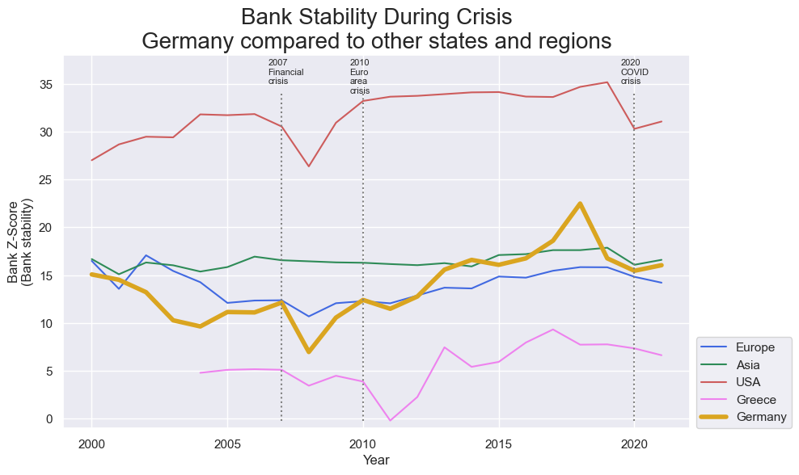

```python
crisis = (2007,2010,2020)
crisis_labels = ("2007\nFinancial\ncrisis\n", "2010\nEuro\narea\ncrisis", "2020\nCOVID\ncrisis\n")

plt.figure(figsize=(10,6))
sns.lineplot(data=df_europe, x='Year', y='GFDD.SI.01', color=Europe, label='Europe', errorbar=('ci',False))
sns.lineplot(data=df_asia, x='Year', y='GFDD.SI.01', color=Asia, label='Asia', errorbar=('ci',False))
sns.lineplot(data=df_usa, x='Year', y='GFDD.SI.01', label='USA', color=USA)
sns.lineplot(data=df_greece, x='Year', y='GFDD.SI.01', label='Greece', color=Greece)
sns.lineplot(data=df_germany, x='Year', y='GFDD.SI.01', label='Germany', linewidth=4, color=Germany)
for i, year in enumerate(crisis):
    plt.annotate(text=crisis_labels[i],xy=(year-0.5,34), fontsize=8)
    plt.vlines(x=year, ymin=df_greece['GFDD.SI.01'].min(), ymax=34, linestyles='dotted', color='grey')
plt.ylim(-1,38)
plt.ylabel("Bank Z-Score\n(Bank stability)")
plt.title("Bank Stability During Crisis\nGermany compared to other states and regions", fontsize=20)
plt.legend(loc=(1.01,0))
plt.show()
```

### Erkenntnisse Bank Z-score

*Weltwirtschaftskrise 2007/2008*

- deutlicher Einbruch des Z-Scores durch die Weltwirtschaftskrise 2007/2008 für Deutschland, Europa und die USA
- das asiatische Finanzsystem blieb während der Weltwirtschaftskrise 2007/2008 stabil
- es zeigt sich eine Erholung aller Finanzsysteme bis zur folgenden Eurokrise

*Eurokrise ab 2010*

- Griechenlands besondere Rolle (Zahlungsunfähigkeit des Landes) in der Eurokrise wird anhand der griechischen Finanzsystem-Stabilität deutlich
- auch in Deutschland und Europa wurde die Finanzsystem-Stabilität angegriffen, aber weniger stark als zur Weltwirtschaftskrise 2007/2008
- die Stabilität der Finanzsysteme der Vereinigten Staaten und des asiatische Wirtschaftsraums waren von der Eurokrise i.S.d. Finanzsystem-Stabilität nicht merklich betroffen

*Coronarise 2020*

- deutlicher Rückgang der Finanzsystem-Stabilität in Deutschland zu Beginn der Corona-Pandemie, aber auch in den USA, Europa und Asien

**Insgesamt zeigt sich eine kontinuierliche Stabilisierung des deutschen Finanzsystems über die Zeit, welche durch Krisen kurzzeitig zurückgeht.**

## Bank non-performing loans to gross loans (%), Code: GFDD.SI.02

Die non-performing loans to gross loans (NPL-Rate) zeigt den Anteil "notleidender" Kredite. Die NPL-Rate zeigt:

- wie stark Kreditnehmer ausfallen
- wie problematisch die wirtschaftliche Lage im Inland ist
- ob Banken riskante Kreditpolitik betrieben haben

```python
# Definition der Metrik aus dem Gloassary abrufen

print(f"{glossary[glossary['Series Code']=='GFDD.SI.02']['Series'].iloc[0]}, Code: {glossary[glossary['Series Code']=='GFDD.SI.02']['Series Code'].iloc[0]}")
for line in glossary[glossary['Series Code']=='GFDD.SI.02']['Description'].iloc[0].split('.'):
    if line=="":
        break
    print(str.strip(line), end=".\n")
```

```
Bank non-performing loans to gross loans (%), Code: GFDD.SI.02
Reported by IMF staff.
Note that due to differences in national accounting, taxation, and supervisory regimes, these data are not strictly comparable across countries.
```

**Folgende Fragestellungen werden untersucht:**

1. *Wie beeinflussen Krisen den Anteil notleidender Kredite?*
2. *Wie steht Deutschland im internationalen Vergleich während der Krisen da, besonders im Vergleich zu Krisenherden wie Griechenland während der Eurokrise?*

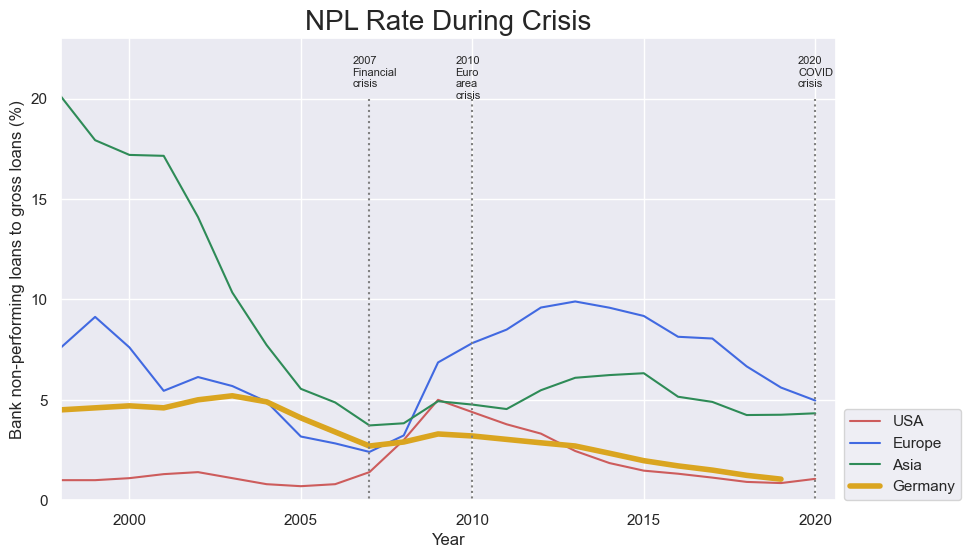

```python
crisis = (2007,2010,2020)
crisis_labels = ("2007\nFinancial\ncrisis\n", "2010\nEuro\narea\ncrisis", "2020\nCOVID\ncrisis\n")

plt.figure(figsize=(10,6))

sns.lineplot(data=df_usa, x='Year', y='GFDD.SI.02', label='USA', color=USA)
sns.lineplot(data=df_europe, x='Year', y='GFDD.SI.02', label='Europe', color=Europe)
sns.lineplot(data=df_asia, x='Year', y='GFDD.SI.02', label='Asia', color=Asia)
sns.lineplot(data=df_germany, x='Year', y='GFDD.SI.02', label='Germany', color=Germany, linewidth=4)
plt.ylim(0,23)
for i, year in enumerate(crisis):
    plt.annotate(text=crisis_labels[i],xy=(year-0.5,20), fontsize=8)
    plt.vlines(x=year, ymin=df_greece['GFDD.SI.01'].min(), ymax=20, linestyles='dotted', color='grey')

plt.xlim(1998,2020.6)

plt.title("NPL Rate During Crisis", fontsize=20)

plt.ylabel("Bank non-performing loans to gross loans (%)")

plt.legend(loc=(1.01,0))

plt.show()
```

### NPL-Ratio mit Griechenland

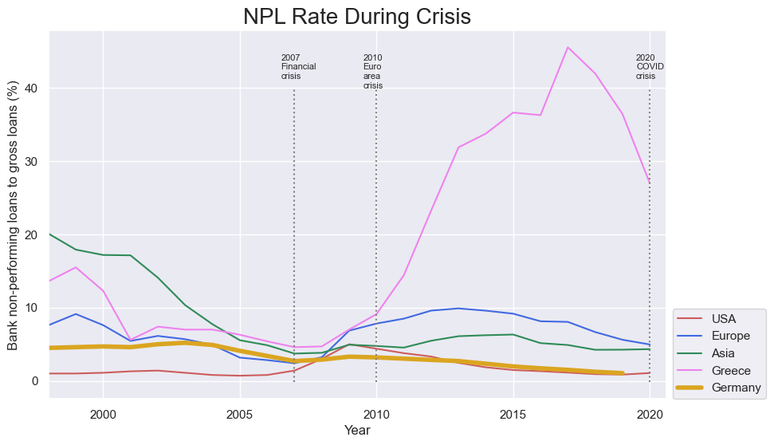

```python
crisis = (2007,2010,2020)
crisis_labels = ("2007\nFinancial\ncrisis\n", "2010\nEuro\narea\ncrisis", "2020\nCOVID\ncrisis\n")

plt.figure(figsize=(10,6))

sns.lineplot(data=df_usa, x='Year', y='GFDD.SI.02', label='USA', color=USA)
sns.lineplot(data=df_europe, x='Year', y='GFDD.SI.02', label='Europe', color=Europe)
sns.lineplot(data=df_asia, x='Year', y='GFDD.SI.02', label='Asia', color=Asia)
sns.lineplot(data=df_greece, x='Year', y='GFDD.SI.02', label='Greece', color=Greece)
sns.lineplot(data=df_germany, x='Year', y='GFDD.SI.02', label='Germany', color=Germany, linewidth=4)

for i, year in enumerate(crisis):
    plt.annotate(text=crisis_labels[i],xy=(year-0.5,40), fontsize=8)
    plt.vlines(x=year, ymin=df_greece['GFDD.SI.01'].min(), ymax=40, linestyles='dotted', color='grey')

plt.xlim(1998,2020.6)

plt.title("NPL Rate During Crisis", fontsize=20)

plt.ylabel("Bank non-performing loans to gross loans (%)")

plt.legend(loc=(1.01,0))

plt.show()
```

### Comparison: Germany x Greece

```python
# gefilterten Datensatz erstellen:
# Filtern nach den Vor-und-Nach-Krisenjahren 2007, 2009, 2012
# sowie nach Deutschland und Griechenland

df_gergre = df_wide[df_wide['Year'].isin([2007,2009,2012])]
df_gergre = df_gergre[df_gergre['Country'].isin(['Greece', 'Germany'])]
```

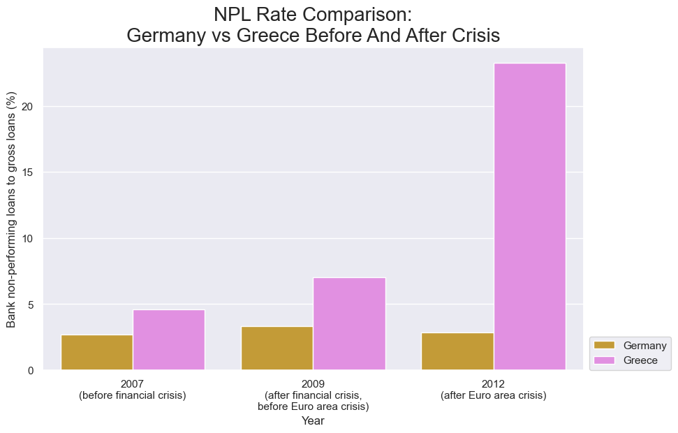

```python
plt.figure(figsize=(10,6))

sns.barplot(data=df_gergre, x='Year', y='GFDD.SI.02', hue='Country', palette=[Germany,Greece])

plt.xticks(ticks=["2007","2009","2012"], labels=["2007\n(before financial crisis)","2009\n(after financial crisis,\nbefore Euro area crisis)","2012\n(after Euro area crisis)"])
plt.ylabel("Bank non-performing loans to gross loans (%)")

plt.title("NPL Rate Comparison:\nGermany vs Greece Before And After Crisis", fontsize=20)

plt.legend(loc=(1.01,0))

plt.show()
```

### Erkenntnisse NPL-Rate

- stark steigende NPL-Rate in Europa nach der Finanzkrise 2007: Kreditprobleme als Vorbote der Eurokrise
- weiterer Anstieg in der Eurokrise 2010
- Griechenland mit enormem Anstieg: mehrfache Rettungspakete durch EU notwendig gewesen, um Bankrott abzuwenden
- Deutschland weniger stark betroffen, was auf konservatives deutsches Bankmodell zurückzuführen ist

## Bank capital to total assets (%), Code: GFDD.SI.03

Bank capital to total assets (%) ist ein Indikator dafür, wie viel „Eigenkapitalpuffer“ Banken haben.  
Je höher der Wert ist, desto mehr Sicherheit besteht im Krisenfall.

Der Eigenkapitalpuffer zeigt damit die Robustheit des Finanzsystems - mit einem höheren Puffer können Banken Verluste besser abfangen.

```python
# Definition der Metrik aus dem Gloassary abrufen

print(f"{glossary[glossary['Series Code']=='GFDD.SI.03']['Series'].iloc[0]}, Code: {glossary[glossary['Series Code']=='GFDD.SI.03']['Series Code'].iloc[0]}")
for line in glossary[glossary['Series Code']=='GFDD.SI.03']['Description'].iloc[0].split('.'):
    if line=="":
        break
    print(str.strip(line), end=".\n")
```

```
Bank capital to total assets (%), Code: GFDD.SI.03
Ratio of bank capital and reserves to total assets.
Capital and reserves include funds contributed by owners, retained earnings, general and special reserves, provisions, and valuation adjustments.
Capital includes tier 1 capital (paid-up shares and common stock), which is a common feature in all countries' banking systems, and total regulatory capital, which includes several specified types of subordinated debt instruments that need not be repaid if the funds are required to maintain minimum …
Total assets include all nonfinancial and financial assets.
Reported by IMF staff.
Note that due to differences in national accounting, taxation, and supervisory regimes, these data are not strictly comparable across countries.
```

**Folgende Fragestellungen werden untersucht:**

1. *Wie entwickelt sich der Eigenkapitalpuffer Deutschlands über die Zeit im internationalen Vergleich?*
2. *Wie beeinflussen Krisen dessen Entwicklung?*

### Bank Capital To Assets Over Time

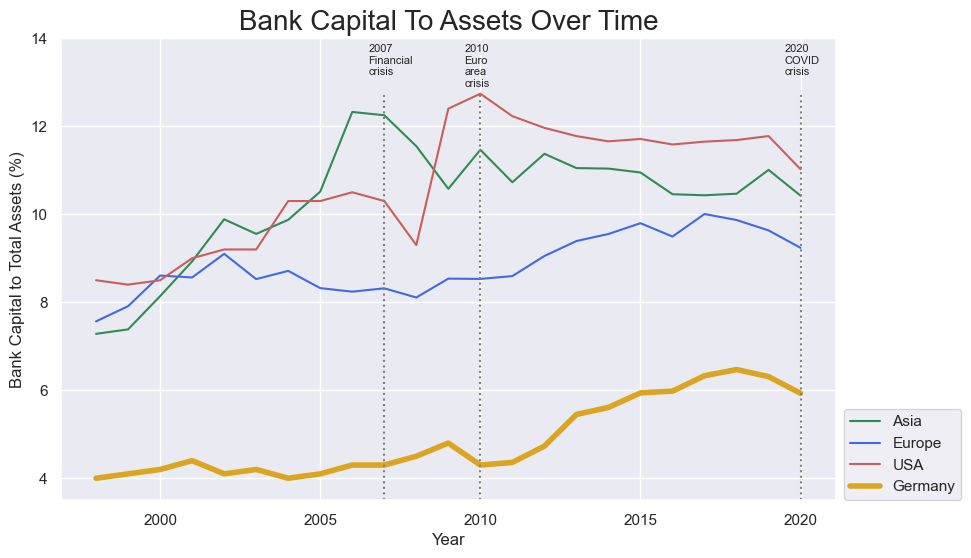

```python
crisis = (2007,2010,2020)
crisis_labels = ("2007\nFinancial\ncrisis\n", "2010\nEuro\narea\ncrisis", "2020\nCOVID\ncrisis\n")

plt.figure(figsize=(10,6))

plt.title("Bank Capital To Assets Over Time", fontsize=20)
plt.ylabel("Bank Capital to Total Assets (%)")

sns.lineplot(data=df_asia, x='Year', y='GFDD.SI.03', label='Asia', color=Asia, errorbar=('ci',False))
sns.lineplot(data=df_europe, x='Year', y='GFDD.SI.03', label='Europe', color=Europe, errorbar=('ci',False))
sns.lineplot(data=df_usa, x='Year', y='GFDD.SI.03', label='USA', color=USA)
sns.lineplot(data=df_germany, y='GFDD.SI.03', x='Year', label='Germany', linewidth=4, color=Germany)

for i, year in enumerate(crisis):
    plt.annotate(text=crisis_labels[i],xy=(year-0.5,12.9), fontsize=8)
    plt.vlines(x=year, ymin=3, ymax=12.7, linestyles='dotted', color='grey')

plt.ylim(3.5,14)

plt.legend(loc=(1.01,0))

plt.show()
```

### Bank Capital of Germany Before and After Crisis

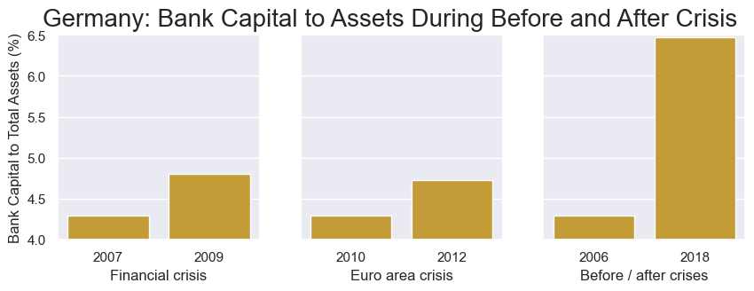

```python
fig, axs = plt.subplots(1,3, figsize=(10,3), sharey=True)
plt.ylim(4,6.5)
sns.barplot(data=df_germany[df_germany['Year'].isin([2007,2009])], x='Year', y='GFDD.SI.03', ax=axs[0], color=Germany)
axs[0].set(xlabel="Financial crisis")

sns.barplot(data=df_germany[df_germany['Year'].isin([2010,2012])], x='Year', y='GFDD.SI.03', ax=axs[1], color=Germany)
axs[1].set(xlabel="Euro area crisis")

sns.barplot(data=df_germany[df_germany['Year'].isin([2006,2018])], x='Year', y='GFDD.SI.03', ax=axs[2], color=Germany)
axs[2].set(xlabel="Before / after crises")

axs[0].set(ylabel="Bank Capital to Total Assets (%)")


plt.suptitle("Germany: Bank Capital to Assets During Before and After Crisis", fontsize=20)

plt.show()
```

### Comparison Germany: Bank Capital x NPL Rate

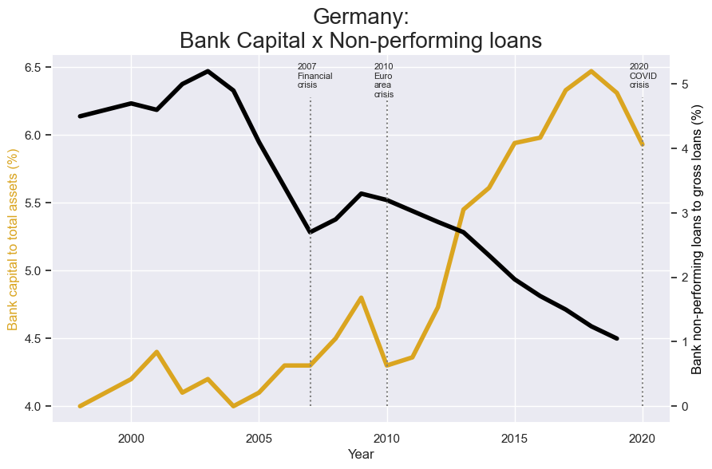

```python
crisis = (2007,2010,2020)
crisis_labels = ("2007\nFinancial\ncrisis\n", "2010\nEuro\narea\ncrisis", "2020\nCOVID\ncrisis\n")

fig, ax1 = plt.subplots(figsize=(10,6))

ax2 = ax1.twinx()
sns.lineplot(data=df_germany, x='Year', y='GFDD.SI.03', ax=ax1, color=Germany, linewidth=4)
sns.lineplot(data=df_germany, x='Year', y='GFDD.SI.02', ax=ax2, color='black', linewidth=4)

for i, year in enumerate(crisis):
    plt.annotate(text=crisis_labels[i],xy=(year-0.5,4.8), fontsize=8)
    plt.vlines(x=year, ymin=0, ymax=4.8, linestyles='dotted', color='grey')

ax1.set_xlabel('Year')
ax1.set_ylabel('Bank capital to total assets (%)', color=Germany)
ax2.set_ylabel('Bank non-performing loans to gross loans (%)', color='black')

ax1.grid(visible=True)
ax2.grid(visible=None)

plt.title('Germany:\nBank Capital x Non-performing loans', fontsize=20)

plt.show()
```

```python
df_germany[['GFDD.SI.03','GFDD.SI.02']].corr()
```

| Series Code | GFDD.SI.03 | GFDD.SI.02 |
| --- | --- | --- |
| GFDD.SI.03 | 1.000000 | -0.885496 |
| GFDD.SI.02 | -0.885496 | 1.000000 |

## Bank cost to income ratio (%), Code: GFDD.EI.07 und Bank return on assets (%, before tax), Code: GFDD.EI.09

Während die Bank cost to income ratio die Effizienz einer Bank abbildet, steht Bank return on assets (ROA) für die Profitabilität.

- je niedriger die Cost-to-income-Rate ist, desto effizienter arbeiten die Banken
- je höher ROA, desto profitabler sind Banken

Finanzstabilität hängt stark davon ab:

- wie profitabel Banken sind
- wie gut sie ihre Kosten kontrollieren können

```python
# Definition der Metriken aus dem Gloassary abrufen

print(f"{glossary[glossary['Series Code']=='GFDD.EI.07']['Series'].iloc[0]}, Code: {glossary[glossary['Series Code']=='GFDD.EI.07']['Series Code'].iloc[0]}")
for line in glossary[glossary['Series Code']=='GFDD.EI.07']['Description'].iloc[0].split('.'):
    if line=="":
        break
    print(str.strip(line), end=".\n")

print("---")

print(f"{glossary[glossary['Series Code']=='GFDD.EI.09']['Series'].iloc[0]}, Code: {glossary[glossary['Series Code']=='GFDD.EI.09']['Series Code'].iloc[0]}")
for line in glossary[glossary['Series Code']=='GFDD.EI.09']['Description'].iloc[0].split('.'):
    if line=="":
        break
    print(str.strip(line), end=".\n")
```

```
Bank cost to income ratio (%), Code: GFDD.EI.07
Operating expenses of a bank as a share of sum of net-interest revenue and other operating income.
Raw data are from Bankscope and Orbis.
The formula applied to Bankscope is data2090 / (data2080 + data2085) and a comparable approach is applied to Orbis.
All Numerator and denominator are first aggregated on the country level before division.
Note that banks used in the calculation might differ between indicators.
Calculated from underlying bank-by-bank unconsolidated data from Bankscope and Orbis.
The result is not reported if a country-year has less than 3 bank-level observations.
---
Bank return on assets (%, before tax), Code: GFDD.EI.09
Commercial banks’ pre-tax income to yearly averaged total assets.
Raw data are from Bankscope and Orbis.
The formula applied to Bankscope is data10270[t] / ((data2025[t] + data2025[t-1])/2) and a comparable approach is applied to Orbis.
Numerator and denominator are first aggregated on the country level before division.
Note that banks used in the calculation might differ between indicators.
Calculated from underlying bank-by-bank unconsolidated data from Bankscope and Orbis.
The result is not reported if a country-year has less than 3 bank-level observations.
```

**Folgende Fragestellungen werden untersucht:**

1. *Wie steht es um Effizienz und Profitabilität des deutschen Finanzsystems im internationalen Vergleich?*
2. *Wie beeinflussen Krisen Effizienz und Profitabilität?*

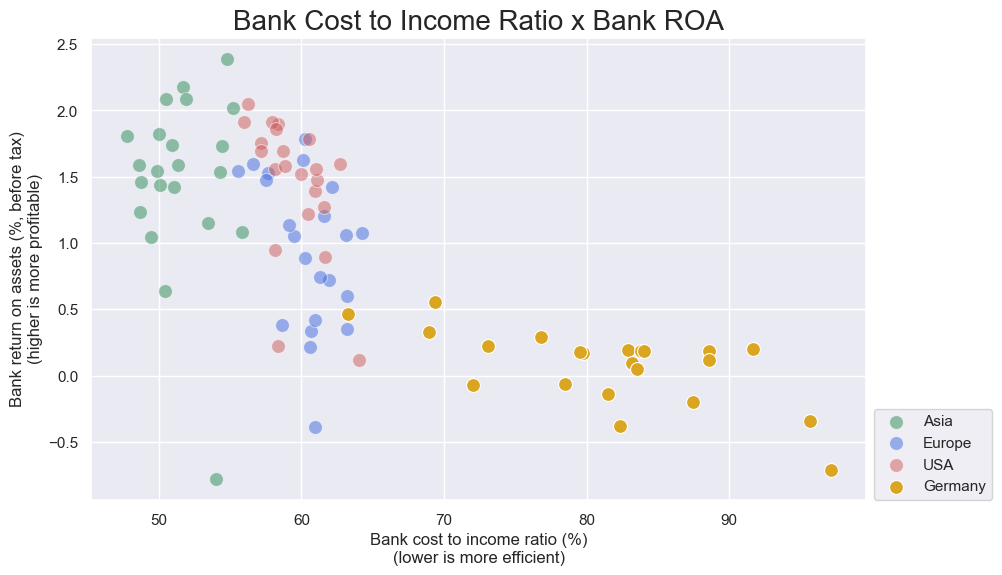

```python
plt.figure(figsize=(10,6))

sns.scatterplot(df_asia, x='GFDD.EI.07', y='GFDD.EI.09', color=Asia, alpha=0.5, label='Asia', s=100)
sns.scatterplot(df_europe, x='GFDD.EI.07', y='GFDD.EI.09', color=Europe, alpha=0.5, label='Europe', s=100)
sns.scatterplot(df_usa, x='GFDD.EI.07', y='GFDD.EI.09', color=USA, alpha=0.5, label='USA', s=100)
sns.scatterplot(df_germany, x='GFDD.EI.07', y='GFDD.EI.09', color=Germany, alpha=1, label='Germany', s=100)

plt.xlabel("Bank cost to income ratio (%)\n(lower is more efficient)")
plt.ylabel("Bank return on assets (%, before tax)\n(higher is more profitable)")

plt.title("Bank Cost to Income Ratio x Bank ROA", fontsize=20)

plt.legend(loc=(1.01,0))

plt.show()
```

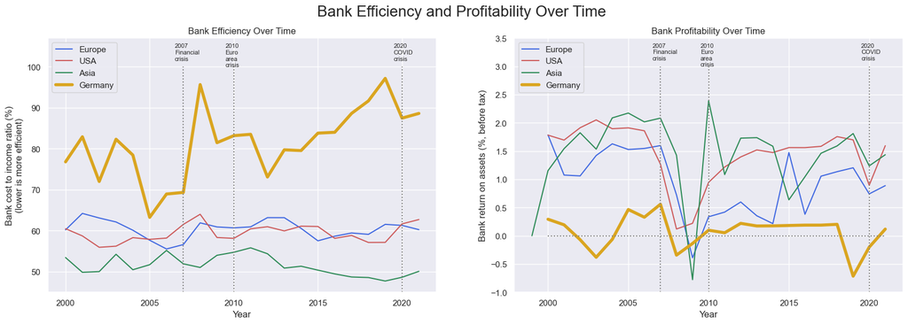

```python
fig, ax = plt.subplots(1,2, figsize=(20,6))

# Graph 1
sns.lineplot(df_europe, x='Year', y='GFDD.EI.07', color=Europe, label='Europe', errorbar=('ci',False), ax=ax[0])
sns.lineplot(df_usa, x='Year', y='GFDD.EI.07', color=USA, label='USA', ax=ax[0])
sns.lineplot(df_asia, x='Year', y='GFDD.EI.07', color=Asia, label='Asia', errorbar=('ci',False), ax=ax[0])
sns.lineplot(df_germany, x='Year', y='GFDD.EI.07', color=Germany, label='Germany', linewidth=4, ax=ax[0])


for i, year in enumerate(crisis):
    ax[0].annotate(text=crisis_labels[i],xy=(year-0.5,100), fontsize=8)
    ax[0].vlines(x=year, ymin=45, ymax=100, linestyles='dotted', color='grey')

ax[0].set(ylim=(45,107), title="Bank Efficiency Over Time", ylabel="Bank cost to income ratio (%)\n(lower is more efficient)")


# Graph 2
sns.lineplot(df_europe, x='Year', y='GFDD.EI.09', color=Europe, label='Europe', errorbar=('ci',False), ax=ax[1])
sns.lineplot(df_usa, x='Year', y='GFDD.EI.09', color=USA, label='USA', ax=ax[1])
sns.lineplot(df_asia, x='Year', y='GFDD.EI.09', color=Asia, label='Asia', errorbar=('ci',False), ax=ax[1])
sns.lineplot(df_germany, x='Year', y='GFDD.EI.09', color=Germany, linewidth=4,label='Germany', ax=ax[1])

plt.ylim(-1,3.5)
for i, year in enumerate(crisis):
    plt.annotate(text=crisis_labels[i],xy=(year-0.5,3), fontsize=8)
    plt.vlines(x=year, ymin=-1, ymax=3, linestyles='dotted', color='grey')
plt.hlines(y=0, xmin=2000, xmax=2021, color='grey', linestyle='dotted')

ax[1].set(ylim=(-1,3.5), title="Bank Profitability Over Time", ylabel="Bank return on assets (%, before tax)")

plt.suptitle("Bank Efficiency and Profitability Over Time", fontsize=20)

plt.show()
```

### Erkenntnisse Effizienz und Profitabilität

- Deutsche Banken arbeiten verhältnismäßig ineffizient und unprofitabel
- starker Einbruch der Profitabilität der Banken in Asien, Europa und den USA durch die globale Finanzkrise 2007

# Finanzielle Inklusion

**Folgende Fragestellungen werden untersucht:**

1. *Wie steht es um den Zugang zu Finanzdienstleistungen der Deutschen im internationalen Vergleich?*
2. *Wie ist die Entwicklung der Finanzinfrastruktur deutschlands im internationalen Vergleich?*
3. *Beeinflussen Krisen die Entwicklung der Finanzinfrastruktur oder handelt es sich um eine krisenunabhängige, strukturelle Entwicklung?*

## Account at a formal financial institution (% age 15+), Code: GFDD.AI.05

Zunächst soll die Frage geklärt werden, wie viele Menschen in Deutschland, im Vergleich zu den USA, Europa und Asien, ein Bankkonto haben.

```python
# Definition der Metrik aus dem Gloassary abrufen

print(f"{glossary[glossary['Series Code']=='GFDD.AI.05']['Series'].iloc[0]}, Code: {glossary[glossary['Series Code']=='GFDD.AI.05']['Series Code'].iloc[0]}")
for line in glossary[glossary['Series Code']=='GFDD.AI.05']['Description'].iloc[0].split('. '):
    if line=="":
        break
    if line != glossary[glossary['Series Code']=='GFDD.AI.05']['Description'].iloc[0].split('. ')[-1]:
        print(str.strip(line), end=".\n")
    else:
        print(str.strip(line))
```

```
Account at a formal financial institution (% age 15+), Code: GFDD.AI.05
The percentage of respondents with an account (self or together with someone else) at a bank, credit union, another financial institution (e.g., cooperative, microfinance institution), or the post office (if applicable) including respondents who reported having a debit card (% age 15+).
The values correspond to Global Findex variable fin1_t_a.
```

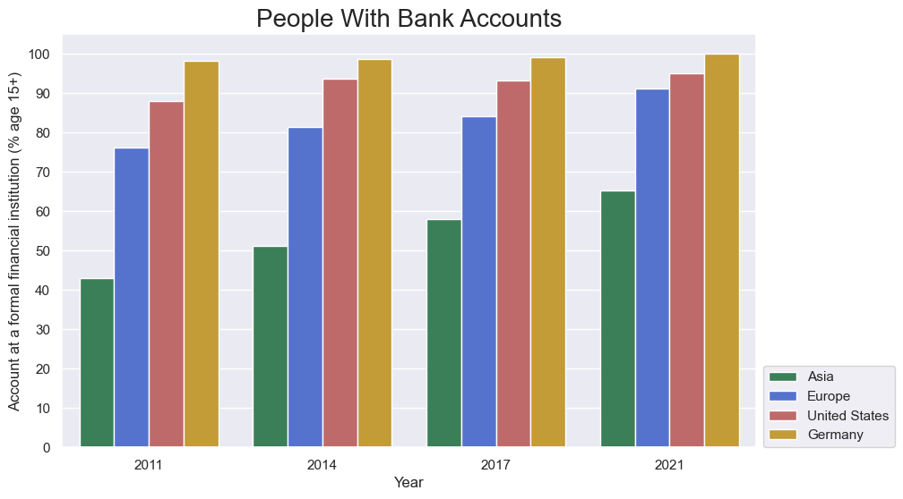

```python
# Erstellen des gefilterten Datensatzes:
# Länder und Regionen: Asien, Europa, USA, Deutschland
# Jahre mit Daten zur Metrik: 2011, 2014, 2017, 2021

choice = ['Asia','Europe','United States','Germany']
data = df_wide[df_wide['Country'].isin(choice)]
data = data[data['Year'].isin([2011,2014,2017,2021])]
data = data[['Country','Year','GFDD.AI.05']].sort_values(by=['Year','GFDD.AI.05'])


plt.figure(figsize=(10,6))

sns.barplot(data=data, x='Year', y='GFDD.AI.05', hue='Country',palette=[Asia,Europe,USA,Germany])

plt.title("People With Bank Accounts", fontsize=20)

plt.ylabel("Account at a formal financial institution (% age 15+)")
plt.yticks(ticks=np.arange(0,101,10))

plt.legend(loc=(1.01,0))

plt.show()
```

### Erkenntnisse Zugang zu Bankkonten

- der Zugang zu Bankkonten ist sowohl in Deutschland, den USA, Europa und Asien seit 2011 stetig gestiegen
- während in Deutschland bereits seit 2011 annähernd jeder ein Bankkonto besitzt, sieht dies in den weiteren Vergleichsregionen anders aus:
  - Asien konnte sich von etwas über 40% im Jahr 2011 auf etwa 65% im Jahr 2021 stark verbessern
  - auch in Europa und den USA haben im Laufe der Zeit immer mehr Personen ein Bankkonto erhalten
  - während bereits seit 2014 über 90% der US-Bürger ein Bankkonto haben, konnte der europäische Durchschnitt diesen Wert erst ab 2021 erreichen

## Bank branches per 100,000 adults, Code: GFDD.AI.02

Wie hat sich das Bankfilialnetz über die Zeit entwickelt?

```python
# Definition der Metrik aus dem Gloassary abrufen

print(f"{glossary[glossary['Series Code']=='GFDD.AI.02']['Series'].iloc[0]}, Code: {glossary[glossary['Series Code']=='GFDD.AI.02']['Series Code'].iloc[0]}")
for line in glossary[glossary['Series Code']=='GFDD.AI.02']['Description'].iloc[0].split('. '):
    if line=="":
        break
    if line != glossary[glossary['Series Code']=='GFDD.AI.02']['Description'].iloc[0].split('. ')[-1]:
        print(str.strip(line), end=".\n")
    else:
        print(str.strip(line))
```

```
Bank branches per 100,000 adults, Code: GFDD.AI.02
For each country calculated as: 100,000*reported number of commercial bank branches/adult population in the reporting country.
```

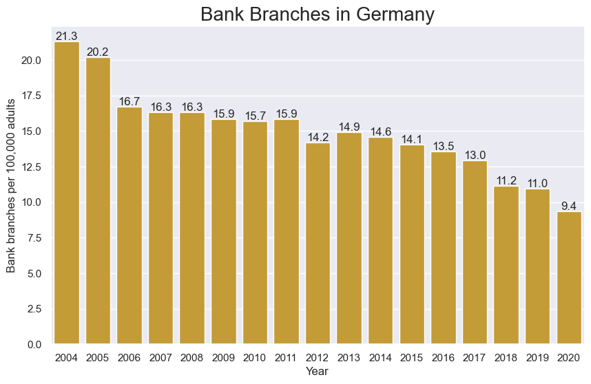

```python
data = df_germany.dropna(subset='GFDD.AI.02')

plt.figure(figsize=(10,6))
sns.barplot(data=data, x='Year', y='GFDD.AI.02', color=Germany)

plt.title("Bank Branches in Germany", fontsize=20)
plt.ylabel("Bank branches per 100,000 adults")

for year in df_germany.dropna(subset='GFDD.AI.02')['Year'].unique():
    plt.annotate(text=data[data['Year']==year]['GFDD.AI.02'].iloc[0].round(1), xy=(str(year),data[data['Year']==year]['GFDD.AI.02'].iloc[0]+0.1), ha='center')

plt.show()
```

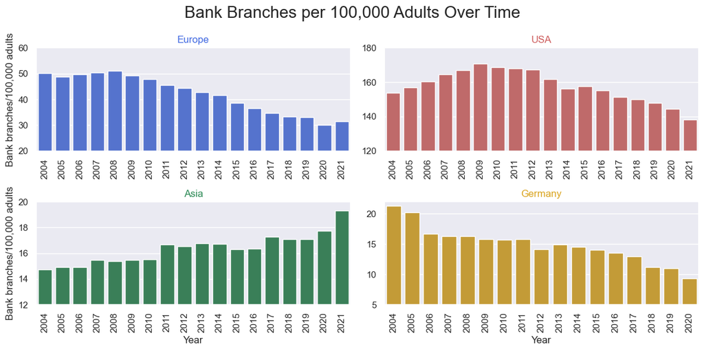

```python
# Daten vorbereiten
data_europe = df_europe.dropna(subset='GFDD.AI.02')
data_usa = df_usa.dropna(subset='GFDD.AI.02')
data_asia = df_asia.dropna(subset='GFDD.AI.02')
data_germany = df_germany.dropna(subset='GFDD.AI.02')

# Ticks für xticks generieren
years_str_eur = [str(year) for year in data_europe['Year']]
years_str_usa = [str(year) for year in data_usa['Year']]
years_str_asi = [str(year) for year in data_asia['Year']]
years_str_ger = [str(year) for year in data_germany['Year']]


# Plot
fig, ax = plt.subplots(2,2,figsize=(12,6))



sns.barplot(data=data_europe, x='Year', y='GFDD.AI.02', ax=ax[0,0], color=Europe, label='Europe', legend=False)
sns.barplot(data=data_usa, x='Year', y='GFDD.AI.02', ax=ax[0,1], color=USA, label='USA', legend=False)
sns.barplot(data=data_asia, x='Year', y='GFDD.AI.02', ax=ax[1,0], color=Asia, label='Asia', legend=False)
sns.barplot(data=data_germany, x='Year', y='GFDD.AI.02', ax=ax[1,1], color=Germany, label='Germany', legend=False)


# Achsenbeschriftungen und -formatierung
ax[0,0].set_title(label="Europe", color=Europe)
ax[0,0].set_xlabel(xlabel="")
ax[0,0].set_ylabel("Bank branches/100,000 adults")
ax[0,0].set_ylim(20,60)
ax[0,0].set_xticks(ticks=years_str_eur)
ax[0,0].set_xticklabels(labels=data_europe['Year'], rotation=90)

ax[0,1].set_title(label="USA", color=USA)
ax[0,1].set_xlabel(xlabel="")
ax[0,1].set_ylim(120,180)
ax[0,1].set_ylabel("")
ax[0,1].set_xticks(ticks=years_str_usa)
ax[0,1].set_xticklabels(labels=data_usa['Year'], rotation=90)

ax[1,0].set_title(label="Asia", color=Asia)
ax[1,0].set_ylim(12,20)
ax[1,0].set_ylabel("Bank branches/100,000 adults")
ax[1,0].set_xticks(ticks=years_str_asi)
ax[1,0].set_xticklabels(labels=data_asia['Year'], rotation=90)

ax[1,1].set_title(label="Germany", color=Germany)
ax[1,1].set_ylim(5,22)
ax[1,1].set_ylabel("")
ax[1,1].set_xticks(ticks=years_str_ger)
ax[1,1].set_xticklabels(labels=data_germany['Year'], rotation=90)

plt.suptitle('Bank Branches per 100,000 Adults Over Time', fontsize=20)

plt.tight_layout()

plt.show()
```

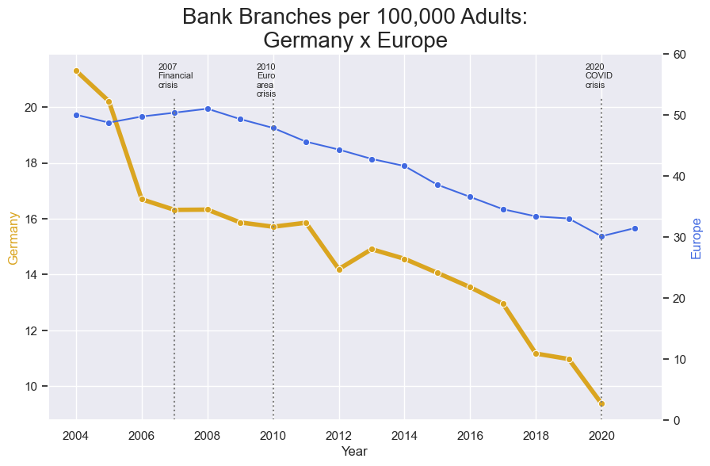

```python
fig, ax1 = plt.subplots(figsize=(10,6))

ax2 = ax1.twinx()
sns.lineplot(data=df_germany, x='Year', y='GFDD.AI.02', ax=ax1, color=Germany, marker='o', linewidth=4)
sns.lineplot(data=df_europe, x='Year', y='GFDD.AI.02', ax=ax2, color=Europe, marker='o')

ax1.set_xlabel('Year')
ax1.set_ylabel('Germany', color=Germany)
ax2.set(ylim=(0,60))
ax2.set_ylabel('Europe', color=Europe)


plt.xticks(ticks=np.arange(2004,2021,2), labels=np.arange(2004,2021,2))

ax2.grid(None)

crisis = (2007,2010,2020)
crisis_labels = ("2007\nFinancial\ncrisis\n", "2010\nEuro\narea\ncrisis", "2020\nCOVID\ncrisis\n")

for i, year in enumerate(crisis):
    ax2.annotate(text=crisis_labels[i],xy=(year-0.5,53), fontsize=8)
    ax2.vlines(x=year, ymin=0, ymax=53, linestyles='dotted', color='grey')

plt.title('Bank Branches per 100,000 Adults:\nGermany x Europe', fontsize=20)

plt.show()
```

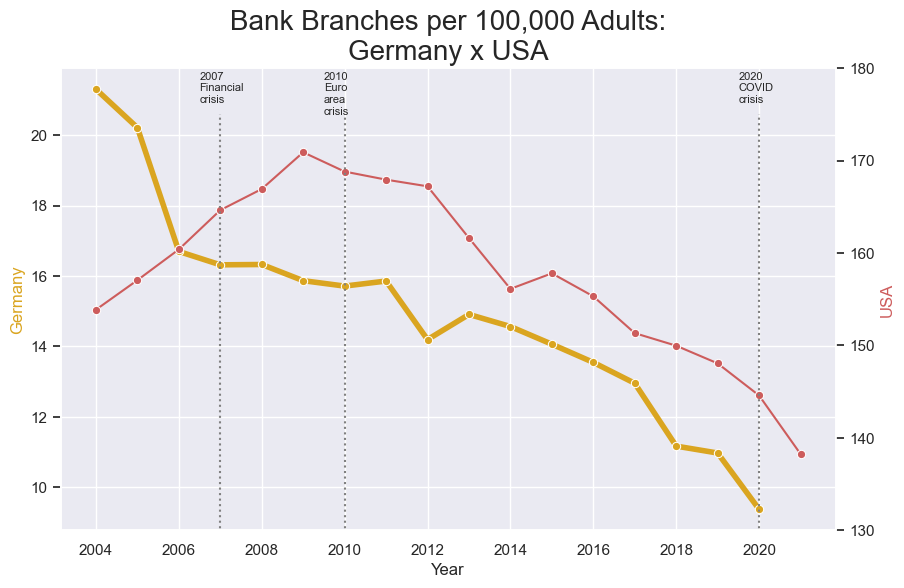

```python
fig, ax1 = plt.subplots(figsize=(10,6))

ax2 = ax1.twinx()
sns.lineplot(data=df_germany, x='Year', y='GFDD.AI.02', ax=ax1, color=Germany, marker='o', linewidth=4)
sns.lineplot(data=df_usa, x='Year', y='GFDD.AI.02', ax=ax2, color=USA, marker='o')

ax1.set_xlabel('Year')
ax1.set_ylabel('Germany', color=Germany)
ax2.set(ylim=(130,180))
ax2.set_ylabel('USA', color=USA)


plt.xticks(ticks=np.arange(2004,2021,2), labels=np.arange(2004,2021,2))

ax2.grid(None)

crisis = (2007,2010,2020)
crisis_labels = ("2007\nFinancial\ncrisis\n", "2010\nEuro\narea\ncrisis", "2020\nCOVID\ncrisis\n")

for i, year in enumerate(crisis):
    ax2.annotate(text=crisis_labels[i],xy=(year-0.5,175), fontsize=8)
    ax2.vlines(x=year, ymin=0, ymax=175, linestyles='dotted', color='grey')

plt.title('Bank Branches per 100,000 Adults:\nGermany x USA', fontsize=20)

plt.show()
```

### Erkenntnisse Filialnetz

- in Deutschland gibt es immer weniger Bankfilialen
- die Anzahl deutscher Bankfilialen sinkt kontinuierlich seit (mindestens) 2004 --> sog. "Filialsterben"
- in Europa ist eine ähnliche Entiwcklung zu beobachten
- in den USA wuchs die Anzahl der Bankfilialen bis 2009, schrumpft seit dem aber auch stark
- lediglich in Asien wird das Bankfilialnetz immer größer
- es zeigt sich kein klarer Zusammenhang zu Krisen: deutet auf krisenunabhängigen, strukturellen Wandel hin

## ATMs per 100,000 adults, Code: GFDD.AI.25

```python
print(f"{glossary[glossary['Series Code']=='GFDD.AI.25']['Series'].iloc[0]}, Code: {glossary[glossary['Series Code']=='GFDD.AI.25']['Series Code'].iloc[0]}")
for line in glossary[glossary['Series Code']=='GFDD.AI.25']['Description'].iloc[0].split('. '):
    if line=="":
        break
    print(str.strip(line))
```

```
ATMs per 100,000 adults, Code: GFDD.AI.25
For each country calculated as: 100,000*Number of ATMs/adult population in the reporting country.
```

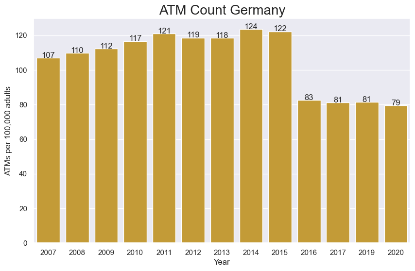

```python
plt.figure(figsize=(10,6))
sns.barplot(data=df_germany.dropna(subset='GFDD.AI.25'), x='Year', y='GFDD.AI.25', color=Germany)

plt.ylabel("ATMs per 100,000 adults")
plt.title("ATM Count Germany", fontsize=20)

for year in df_germany.dropna(subset='GFDD.AI.25')['Year'].unique():
    plt.annotate(text=int(data[data['Year']==year]['GFDD.AI.25'].iloc[0].round(0)), xy=(str(year),data[data['Year']==year]['GFDD.AI.25'].iloc[0]+0.1), ha='center')

plt.show()
```

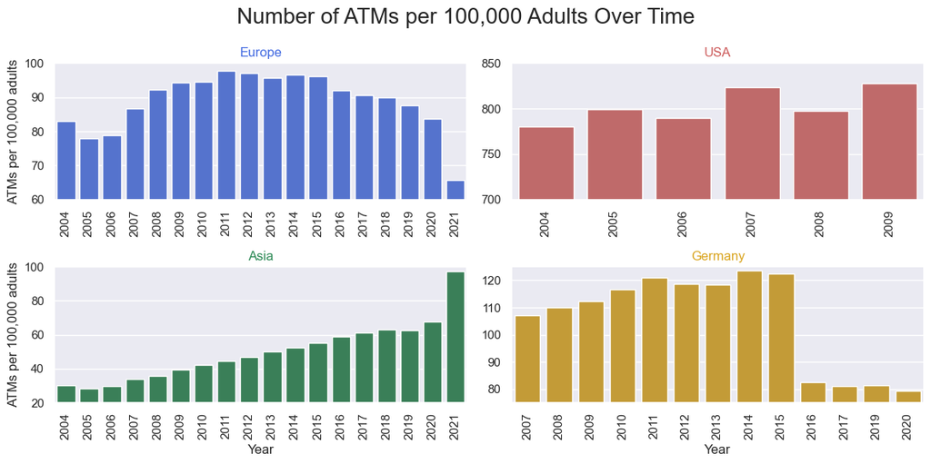

```python
# Daten vorbereiten
data_europe = df_europe.dropna(subset='GFDD.AI.25')
data_usa = df_usa.dropna(subset='GFDD.AI.25')
data_asia = df_asia.dropna(subset='GFDD.AI.25')
data_germany = df_germany.dropna(subset='GFDD.AI.25')

# Ticks für xticks generieren
years_str_eur = [str(year) for year in data_europe['Year']]
years_str_usa = [str(year) for year in data_usa['Year']]
years_str_asi = [str(year) for year in data_asia['Year']]
years_str_ger = [str(year) for year in data_germany['Year']]


# Plot
fig, ax = plt.subplots(2,2,figsize=(12,6), sharex=False)

sns.barplot(data=data_europe, x='Year', y='GFDD.AI.25', color=Europe, label='Europe', legend=False, ax=ax[0,0])
sns.barplot(data=data_usa, x='Year', y='GFDD.AI.25', color=USA, label='USA', legend=False, ax=ax[0,1])
sns.barplot(data=data_asia, x='Year', y='GFDD.AI.25', color=Asia, label='Asia', legend=False, ax=ax[1,0])
sns.barplot(data=data_germany, x='Year', y='GFDD.AI.25', color=Germany, label='Germany', legend=False, ax=ax[1,1])

# Achsenbeschriftungen und -formatierung
ax[0,0].set_title(label="Europe", color=Europe)
ax[0,0].set_xlabel(xlabel="")
ax[0,0].set_ylabel("ATMs per 100,000 adults")
ax[0,0].set_ylim(60,100)
ax[0,0].set_xticks(ticks=years_str_eur)
ax[0,0].set_xticklabels(labels=data_europe['Year'], rotation=90)

ax[0,1].set_title(label="USA", color=USA)
ax[0,1].set_xlabel(xlabel="")
ax[0,1].set_ylim(700,850)
ax[0,1].set_ylabel("")
ax[0,1].set_xticks(ticks=years_str_usa)
ax[0,1].set_xticklabels(labels=data_usa['Year'], rotation=90)

ax[1,0].set_title(label="Asia", color=Asia)
ax[1,0].set_ylim(20,100)
ax[1,0].set_ylabel("ATMs per 100,000 adults")
ax[1,0].set_xticks(ticks=years_str_asi)
ax[1,0].set_xticklabels(labels=data_asia['Year'], rotation=90)

ax[1,1].set_title(label="Germany", color=Germany)
ax[1,1].set_ylim(75,125)
ax[1,1].set_ylabel("")
ax[1,1].set_xticks(ticks=years_str_ger)
ax[1,1].set_xticklabels(labels=data_germany['Year'], rotation=90)

plt.suptitle('Number of ATMs per 100,000 Adults Over Time', fontsize=20)

plt.tight_layout()

plt.show()
```

### Erkenntnisse Bankautomaten

- bis etwa 2015: steigende Anzahl an Bankautomaten in Deutschland
  - Vermutung: weniger Filialen --> mehr Bankautomaten
- 2016: plötzlicher Einbruch der Anzahl der Bankautomaten in Deutschland
  - Vermutung: erhöhtes Aufkommen der Möglichkeit der Bargeldabhebung in Supermärkten senken den Bedarf an Bargeldautomaten
- in Europa Rückgang an Bankautomaten ab etwa 2015
- in den USA Anstieg der Anzahl an Bankautomaten von 2004 - 2009 (keine weiteren Daten vorhanden)
- stetiger und seit 2020 rasanter Anstieg der Anzahl Bankautomaten in Asien

## Finanzielle Inklusion in Deutschland

Die eben analysierten Daten zeigen: Sowohl die Anzahl an Bankfilialen als auch die Anzahl an Bankautomaten gingen in Deutschland zuletzt kontinuierlich zurück.

Für Deutschland wird dies nochmals genauer untersucht:

```python
# Erstellen einer Korrelationsmatrix für finanzielle Inklusion in Deutschland

inclusion_corr = df_germany[['GFDD.SI.01']+inclusion].corr()
inclusion_corr.rename(columns={
    'GFDD.SI.01': 'Bank Z-score',
    'GFDD.AI.05': 'Adults with bank accounts',
    'GFDD.AI.02': 'Bank branches / 100k adults',
    'GFDD.AI.25': 'ATMs / 100k adults'
    },
    index={
        'GFDD.SI.01': 'Bank Z-score',
        'GFDD.AI.05': 'Adults with bank accounts',
        'GFDD.AI.02': 'Bank branches / 100k adults',
        'GFDD.AI.25': 'ATMs / 100k adults'
        }, inplace=True)
inclusion_corr
```

| Series Code | Bank Z-score | Adults with bank accounts | Bank branches / 100k adults | ATMs / 100k adults |
| --- | --- | --- | --- | --- |
| Bank Z-score | 1.000000 | 0.601540 | -0.718617 | -0.445165 |
| Adults with bank accounts | 0.601540 | 1.000000 | -0.979340 | -0.755918 |
| Bank branches / 100k adults | -0.718617 | -0.979340 | 1.000000 | 0.735367 |
| ATMs / 100k adults | -0.445165 | -0.755918 | 0.735367 | 1.000000 |

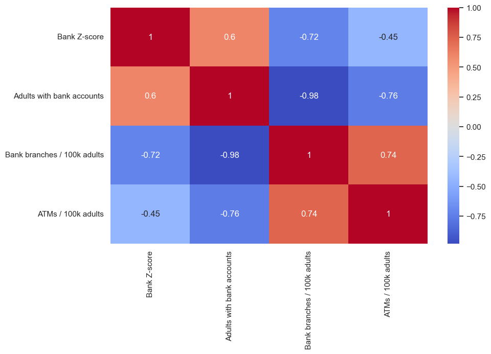

```python
plt.figure(figsize=(10,6))

sns.heatmap(inclusion_corr, annot=True, cmap='coolwarm')
plt.xlabel("")
plt.ylabel("")

plt.show()
```

Die teilweise recht starken Korrelationen von Bank Z-score mit

- Erwachsenen mit Bankkonto (r=0,6),
- Anzahl an Bankfilialen (r=-0,72) und
- Anzahl an Geldautomaten (r=-0,45)

lassen einen Zusammenhang zwischen Finanzsystem-Stabilität und finanzieller Inklusion vermuten.

Dieser potenzielle Zusammenhang soll grafisch näher untersucht werden:

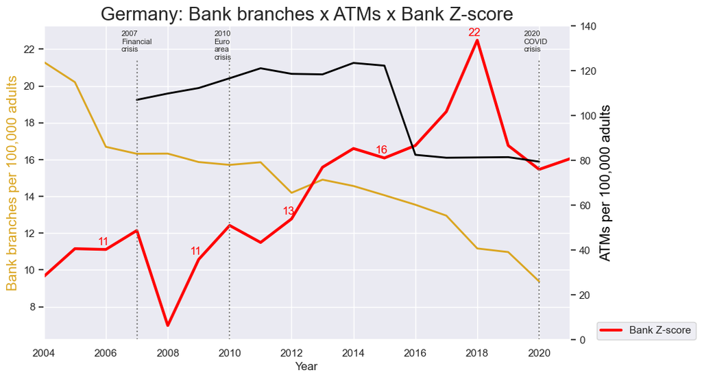

```python
fig, ax1 = plt.subplots(figsize=(10,6))

ax2 = ax1.twinx()
sns.lineplot(data=df_germany, x='Year', y='GFDD.AI.02', ax=ax1, color=Germany, linewidth=2)
sns.lineplot(data=df_germany, x='Year', y='GFDD.AI.25', ax=ax2, color='black', linewidth=2)
sns.lineplot(data=df_germany, x='Year', y='GFDD.SI.01', ax=ax1, label='Bank Z-score', linewidth=3, color='red')

ax1.set_xlabel('Year')
ax1.set_ylabel('Bank branches per 100,000 adults', color=Germany, fontsize=15)
ax2.set_ylabel('ATMs per 100,000 adults', color='black', fontsize=15)
ax2.set(ylim=(0,140))
ax1.set(xlim=(2004,2021))

plt.grid(None)

plt.xticks(ticks=np.arange(2004,2021,2), labels=np.arange(2004,2021,2))

crisis = (2007,2010,2020)
crisis_labels = ("2007\nFinancial\ncrisis\n", "2010\nEuro\narea\ncrisis", "2020\nCOVID\ncrisis\n")

for i, year in enumerate(crisis):
    ax2.annotate(text=crisis_labels[i],xy=(year-0.5,125), fontsize=8)
    ax2.vlines(x=year, ymin=0, ymax=125, linestyles='dotted', color='grey')

for year in np.arange(2006,2021,3):
    ax1.annotate(text=int(df_germany[df_germany['Year'] == year]['GFDD.SI.01'].iloc[0].round(0)), xy=(year-0.1,df_germany[df_germany['Year'] == year]['GFDD.SI.01'].iloc[0]+0.25), color='red', ha='center')

plt.title('Germany: Bank branches x ATMs x Bank Z-score', fontsize=20)

ax1.legend(loc=(1.05,0))

plt.show()
```

# Fazit

Während sich Finanzsystem-Stabilität und finanzielle Inklusion beide über die Zeit verändern, folgen sie unterschiedlichen Dynamiken. Finanzsystem-Stabilität reagiert stark auf konjunkturelle Schocks, während finanzielle Inklusion durch strukturellen Wandel und technologische Entwicklungen geprägt ist. Der deutsche Fall zeigt, dass ein stabiles Finanzsystem den Rückgang physischer Infrastruktur kompensieren kann, ohne die finanzielle Teilhabe der Bevölkerung zu beeinträchtigen.